# NFL Analytics: Next Gen Stats

```r
library(tidyverse)
library(nflverse)
library(gt)
library(ggtext)
library(ggrepel)
library(patchwork)
```

```r
nfl_analytics_theme <- function(..., base_size = 12) {

  theme(
    text = element_text(family = "Roboto",
                        size = base_size,
                        color = "black"),
    axis.ticks = element_blank(),
    axis.title = element_text(face = "bold"),
    axis.text = element_text(face = "bold"),
    plot.title.position = "plot",
    plot.title = element_markdown(size = 16,
                                  vjust = .02,
                                  hjust = 0.5),
    plot.subtitle = element_markdown(hjust = 0.5),
    plot.caption = element_markdown(size = 8),
    panel.grid.minor = element_blank(),
    panel.grid.major =  element_line(color = "#d0d0d0"),
    panel.background = element_rect(fill = "#f7f7f7"),
    plot.background = element_rect(fill = "#f7f7f7"),
    panel.border = element_blank(),
    legend.background = element_rect(color = "#F7F7F7"),
    legend.key = element_rect(color = "#F7F7F7"),
    legend.title = element_text(face = "bold"),
    legend.title.align = 0.5,
    strip.text = element_text(face = "bold"))
}
```

```r
teams <- nflreadr::load_teams()
```

# Passing

```r
ngs_data_passing <- nflreadr::load_nextgen_stats(seasons = 2024,
                                                 stat_type = "passing") %>%
  # does this aggregate the season stats for you?
  filter(week == 0)

names(ngs_data_passing)
```

```
 [1] "season"                                  "season_type"
 [3] "week"                                    "player_display_name"
 [5] "player_position"                         "team_abbr"
 [7] "avg_time_to_throw"                       "avg_completed_air_yards"
 [9] "avg_intended_air_yards"                  "avg_air_yards_differential"
[11] "aggressiveness"                          "max_completed_air_distance"
[13] "avg_air_yards_to_sticks"                 "attempts"
[15] "pass_yards"                              "pass_touchdowns"
[17] "interceptions"                           "passer_rating"
[19] "completions"                             "completion_percentage"
[21] "expected_completion_percentage"          "completion_percentage_above_expectation"
[23] "avg_air_distance"                        "max_air_distance"
[25] "player_gsis_id"                          "player_first_name"
[27] "player_last_name"                        "player_jersey_number"
[29] "player_short_name"
```

```r
ngs_data_passing <- ngs_data_passing %>%
  left_join(teams, b = c("team_abbr" = "team_abbr"))
```

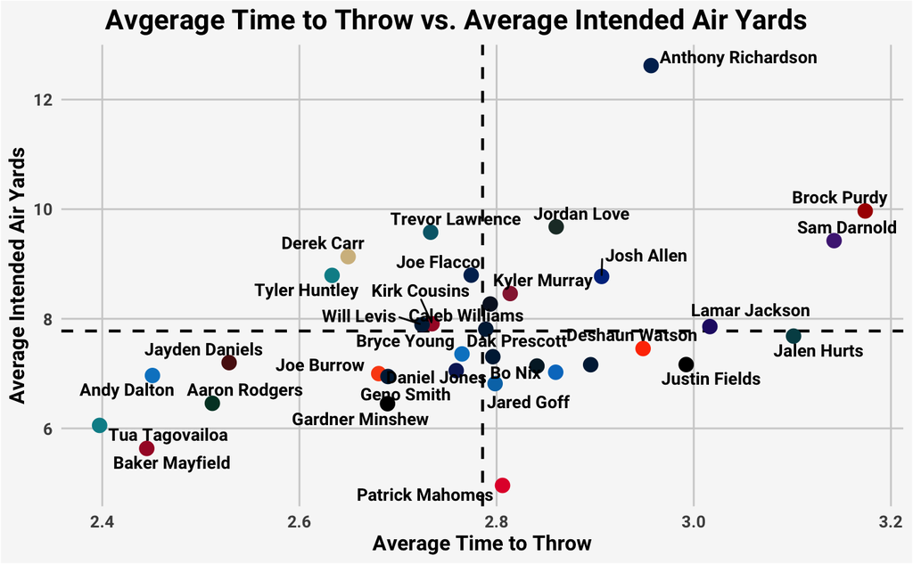

## Pro Football Reference

```r
pfr_stats_pass <- nflreadr::load_pfr_advstats(seasons = 2024,
                                              stat_type = "pass",
                                              summary_level = "season")

pfr_stats_pass$team <- clean_team_abbrs(pfr_stats_pass$team)

pfr_stats_pass <- pfr_stats_pass %>%
  left_join(teams, by = c("team" = "team_abbr"))

names(pfr_stats_pass)
```

```
 [1] "player"               "team"                 "pass_attempts"        "throwaways"           "spikes"
 [6] "drops"                "drop_pct"             "bad_throws"           "bad_throw_pct"        "season"
[11] "pfr_id"               "pocket_time"          "times_blitzed"        "times_hurried"        "times_hit"
[16] "times_pressured"      "pressure_pct"         "batted_balls"         "on_tgt_throws"        "on_tgt_pct"
[21] "rpo_plays"            "rpo_yards"            "rpo_pass_att"         "rpo_pass_yards"       "rpo_rush_att"
[26] "rpo_rush_yards"       "pa_pass_att"          "pa_pass_yards"        "team_name"            "team_id"
[31] "team_nick"            "team_conf"            "team_division"        "team_color"           "team_color2"
[36] "team_color3"          "team_color4"          "team_logo_wikipedia"  "team_logo_espn"       "team_wordmark"
[41] "team_conference_logo" "team_league_logo"     "team_logo_squared"
```

```r
pfr_stats_pass_filtered <- pfr_stats_pass %>%
  filter(pass_attempts >= 60)
```

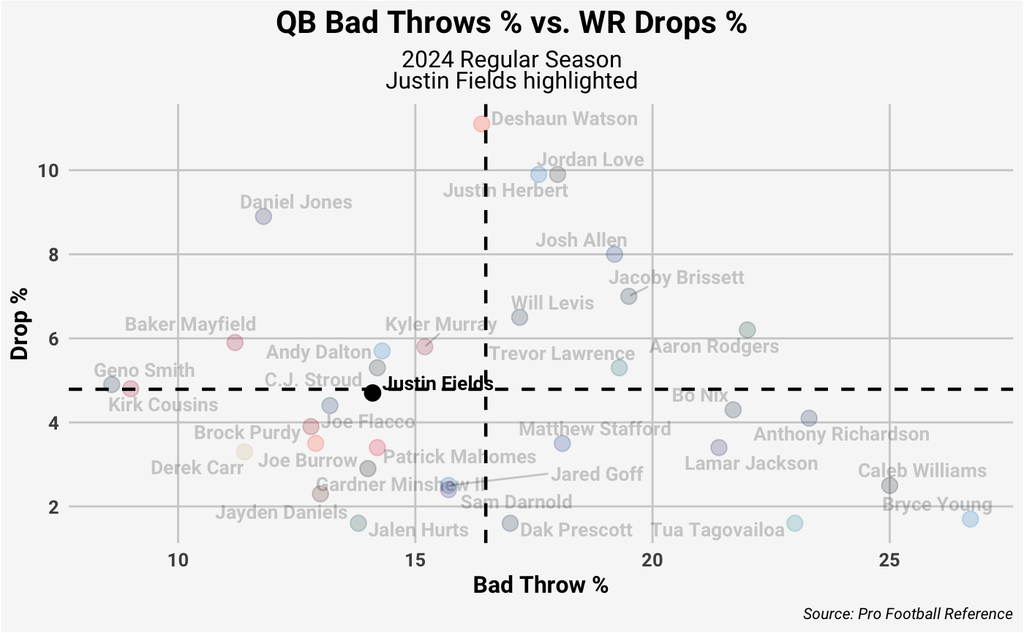

# Rushing

```r
ngs_data_rushing <- nflreadr::load_nextgen_stats(seasons = 2024,
                                                 stat_type = "rushing") %>%
  filter(week == 0) %>%
  mutate(actual_rush_yards = expected_rush_yards + rush_yards_over_expected)

names(ngs_data_rushing)
```

```
 [1] "season"                               "season_type"
 [3] "week"                                 "player_display_name"
 [5] "player_position"                      "team_abbr"
 [7] "efficiency"                           "percent_attempts_gte_eight_defenders"
 [9] "avg_time_to_los"                      "rush_attempts"
[11] "rush_yards"                           "avg_rush_yards"
[13] "rush_touchdowns"                      "player_gsis_id"
[15] "player_first_name"                    "player_last_name"
[17] "player_jersey_number"                 "player_short_name"
[19] "expected_rush_yards"                  "rush_yards_over_expected"
[21] "rush_yards_over_expected_per_att"     "rush_pct_over_expected"
[23] "actual_rush_yards"
```

```r
ngs_data_rushing <- ngs_data_rushing %>%
  left_join(teams, by = c("team_abbr" = "team_abbr"))
```

```r
ngs_data_rushing %>%
  arrange(-percent_attempts_gte_eight_defenders)
```

```
── nflverse Next Gen Stats weekly rushing data ─────────────────────────────────────────────────────────────────────────
ℹ Data updated: 2024-10-13 03:18:39 EDT
```

| season | season_type | week | player_display_name | player_position | team_abbr | efficiency | percent_attempts_gte_eight_defenders | avg_time_to_los | rush_attempts | rush_yards | avg_rush_yards | rush_touchdowns | player_gsis_id | player_first_name | player_last_name | player_jersey_number | player_short_name | expected_rush_yards | rush_yards_over_expected | rush_yards_over_expected_per_att | rush_pct_over_expected | actual_rush_yards | team_name | team_id | team_nick | team_conf | team_division | team_color | team_color2 | … |
| --- | --- | --- | --- | --- | --- | --- | --- | --- | --- | --- | --- | --- | --- | --- | --- | --- | --- | --- | --- | --- | --- | --- | --- | --- | --- | --- | --- | --- | --- | --- |
| 2024 | REG | 0 | Javonte Williams | RB | DEN | 4.121211 | 37.735849 | 2.905932 | 53 | 190 | 3.584906 | 0 | 00-0036997 | Javonte | Williams | 33 | J.Williams | 205.3987 | -22.39874924 | -0.43074518 | 0.4038462 | 183 | Denver Broncos | 1400 | Broncos | AFC | AFC West | #002244 | #FB4F14 | … |
| 2024 | REG | 0 | Jordan Mason | RB | SF | 3.547291 | 36.842105 | 2.841442 | 114 | 609 | 5.342105 | 3 | 00-0037525 | Jordan | Mason | 24 | J.Mason | 398.6557 | 196.34427371 | 1.76886733 | 0.5045045 | 595 | San Francisco 49ers | 4500 | 49ers | NFC | NFC West | #AA0000 | #B3995D | … |
| 2024 | REG | 0 | Zack Moss | RB | CIN | 4.410711 | 35.087719 | 2.883385 | 57 | 211 | 3.701754 | 2 | 00-0036251 | Zaccheus | Moss | 31 | Z.Moss | 212.5493 | -34.54931426 | -0.65187385 | 0.3396226 | 178 | Cincinnati Bengals | 0920 | Bengals | AFC | AFC North | #FB4F14 | #000000 | … |
| 2024 | REG | 0 | Devin Singletary | RB | NYG | 4.120045 | 32.142857 | 2.808400 | 56 | 221 | 3.946429 | 2 | 00-0035250 | Devin | Singletary | 26 | D.Singletary | 230.4269 | -10.42689025 | -0.18957982 | 0.3636364 | 220 | New York Giants | 3410 | Giants | NFC | NFC East | #0B2265 | #A71930 | … |
| 2024 | REG | 0 | James Cook | RB | BUF | 3.653430 | 31.428571 | 2.602111 | 70 | 309 | 4.414286 | 4 | 00-0037248 | James | Cook | 4 | J.Cook | 315.4309 | -10.43092271 | -0.15339592 | 0.3088235 | 305 | Buffalo Bills | 0610 | Bills | AFC | AFC East | #00338D | #C60C30 | … |
| 2024 | REG | 0 | David Montgomery | RB | DET | 3.802915 | 28.571429 | 2.723103 | 63 | 271 | 4.301587 | 4 | 00-0035685 | David | Montgomery | 5 | D.Montgomery | 260.4570 | 5.54298817 | 0.08940304 | 0.4354839 | 266 | Detroit Lions | 1540 | Lions | NFC | NFC North | #0076B6 | #B0B7BC | … |
| 2024 | REG | 0 | Derrick Henry | RB | BAL | 3.013304 | 28.421053 | 2.746118 | 95 | 572 | 6.021053 | 6 | 00-0032764 | Derrick | Henry | 22 | D.Henry | 318.7460 | 229.25400818 | 2.49189139 | 0.4782609 | 548 | Baltimore Ravens | 0325 | Ravens | AFC | AFC North | #241773 | #9E7C0C | … |
| 2024 | REG | 0 | Rhamondre Stevenson | RB | NE | 3.480674 | 27.272727 | 2.810915 | 77 | 356 | 4.623377 | 3 | 00-0036875 | Rhamondre | Stevenson | 38 | R.Stevenson | 243.8700 | 62.13002463 | 0.91367683 | 0.3970588 | 306 | New England Patriots | 3200 | Patriots | AFC | AFC East | #002244 | #C60C30 | … |
| 2024 | REG | 0 | Aaron Jones | RB | MIN | 3.664314 | 26.760563 | 2.796769 | 71 | 350 | 4.929577 | 1 | 00-0033293 | Aaron | Jones | 33 | A.Jones | 292.4906 | 40.50939857 | 0.57870569 | 0.4857143 | 333 | Minnesota Vikings | 3000 | Vikings | NFC | NFC North | #4F2683 | #FFC62F | … |
| 2024 | REG | 0 | Joe Mixon | RB | HOU | 3.895543 | 25.641026 | 2.922784 | 39 | 184 | 4.717949 | 1 | 00-0033897 | Joe | Mixon | 28 | J.Mixon | 161.0321 | 11.96786560 | 0.32345583 | 0.4864865 | 173 | Houston Texans | 2120 | Texans | AFC | AFC South | #03202F | #A71930 | … |

[output cut: 40 more lines]

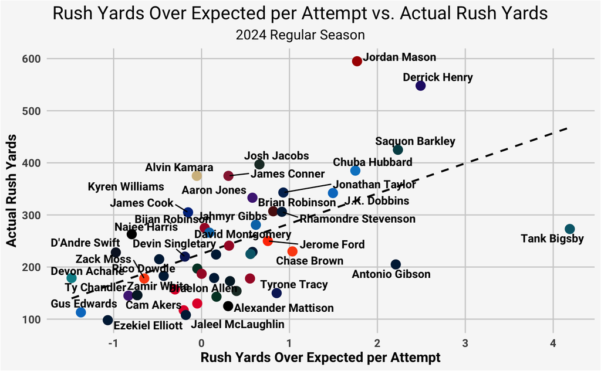

## Pro Football Reference

```r
pfr_stats_rush <- nflreadr::load_pfr_advstats(seasons = 2024,
                                              stat_type = "rush",
                                              summary_level = "season")

pfr_stats_rush$tm <- clean_team_abbrs(pfr_stats_rush$tm)

pfr_stats_rush <- pfr_stats_rush %>%
  left_join(teams, by = c("tm" = "team_abbr"))

names(pfr_stats_rush)
```

```
 [1] "season"               "player"               "pfr_id"               "tm"                   "age"
 [6] "pos"                  "g"                    "gs"                   "att"                  "yds"
[11] "td"                   "x1d"                  "ybc"                  "ybc_att"              "yac"
[16] "yac_att"              "brk_tkl"              "att_br"               "loaded"               "team_name"
[21] "team_id"              "team_nick"            "team_conf"            "team_division"        "team_color"
[26] "team_color2"          "team_color3"          "team_color4"          "team_logo_wikipedia"  "team_logo_espn"
[31] "team_wordmark"        "team_conference_logo" "team_league_logo"     "team_logo_squared"
```

```r
pfr_stats_rush_filtered <- pfr_stats_rush %>%
  filter(pos == 'RB',
         att >= 40)
```

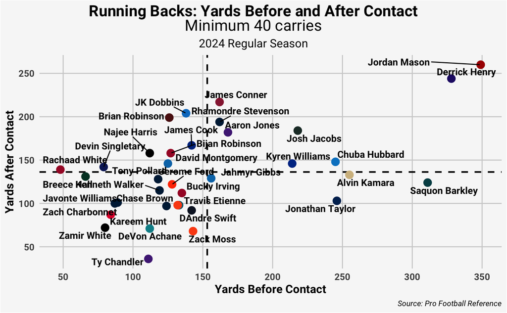

[figure not shown]

# Receiving

```r
pfr_stats_rec <- nflreadr::load_pfr_advstats(seasons = 2024, stat_type = "rec",
                                             summary_level = "season")

pfr_stats_rec <- pfr_stats_rec %>%
  left_join(teams, by = c("tm" = "team_abbr"))

names(pfr_stats_rec)
```

```
 [1] "season"               "player"               "pfr_id"               "tm"                   "age"
 [6] "pos"                  "g"                    "gs"                   "tgt"                  "rec"
[11] "yds"                  "td"                   "x1d"                  "ybc"                  "ybc_r"
[16] "yac"                  "yac_r"                "adot"                 "brk_tkl"              "rec_br"
[21] "drop"                 "drop_percent"         "int"                  "rat"                  "loaded"
[26] "team_name"            "team_id"              "team_nick"            "team_conf"            "team_division"
[31] "team_color"           "team_color2"          "team_color3"          "team_color4"          "team_logo_wikipedia"
[36] "team_logo_espn"       "team_wordmark"        "team_conference_logo" "team_league_logo"     "team_logo_squared"
```

```r
pfr_stats_rec_filtered <- pfr_stats_rec %>%
  filter(rec >= 20 |
         tm == 'PIT' & rec > 5)

pfr_stats_rec_filtered_pit <- pfr_stats_rec %>%
  filter(tm == 'PIT')
```

The below graphic compares the amount of yards at catch with the yards gained after catch.

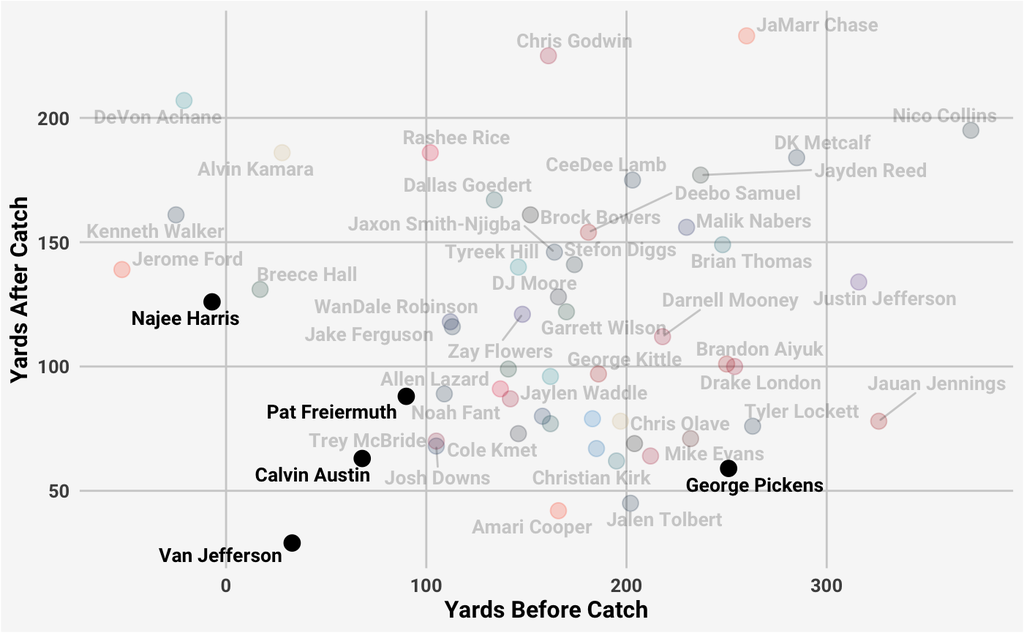

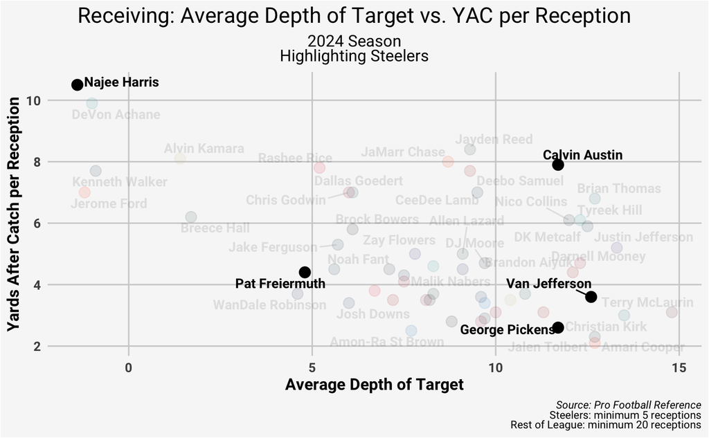

When looking at all Steelers pass catchers, some elements stand out:

- Pittsburgh seems to use personnel at different levels – which is probably also common around the league. Backs are typically catching the ball behind the line of scrimmage. Tight ends and slot options are averaging around 5 yards depth of target. Wide outs are averaging a depth of target beyond 10 yards.
- Connor Heyward is getting some greater depth in his targeting than other TEs (buoyed by his targets against the Cowboys). He’s getting some switch and wheel opportunities that Fields has targeted.
- George Pickens needs to be put in some situations to create after the catch. In the 2023 season, Pickens averaged over 6 yards after catch. So far in 2024, he’s averaging less than 3 yards after the catch.

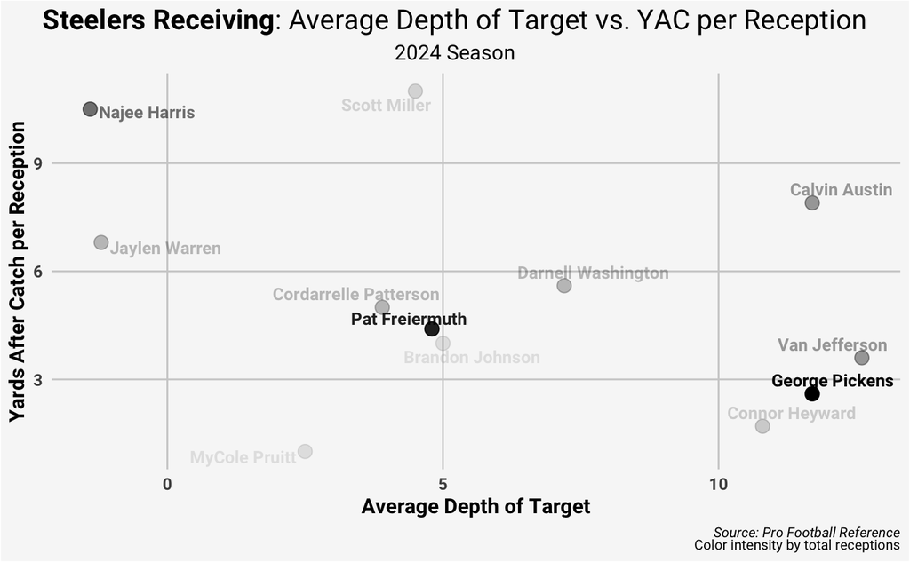

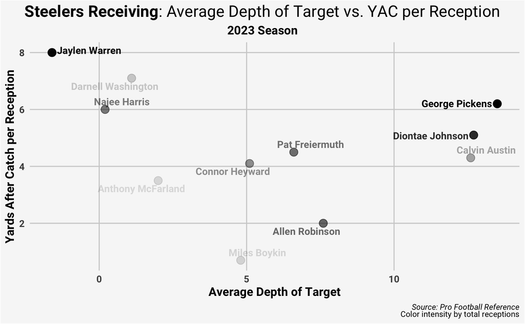

[figure not shown]

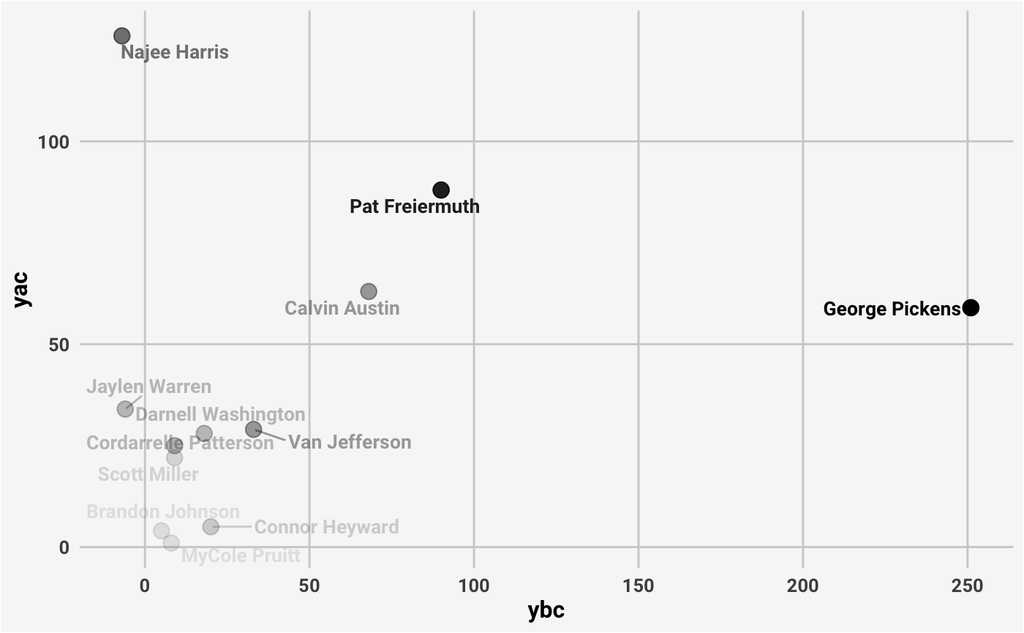

# Defensive stats

## Pro Football Reference

```r
names(pfr_stats_def)
```

```
 [1] "season"               "player"               "pfr_id"               "tm"                   "age"
 [6] "pos"                  "g"                    "gs"                   "int"                  "tgt"
[11] "cmp"                  "cmp_percent"          "yds"                  "yds_cmp"              "yds_tgt"
[16] "td"                   "rat"                  "dadot"                "air"                  "yac"
[21] "bltz"                 "hrry"                 "qbkd"                 "sk"                   "prss"
[26] "comb"                 "m_tkl"                "m_tkl_percent"        "loaded"               "team_name"
[31] "team_id"              "team_nick"            "team_conf"            "team_division"        "team_color"
[36] "team_color2"          "team_color3"          "team_color4"          "team_logo_wikipedia"  "team_logo_espn"
[41] "team_wordmark"        "team_conference_logo" "team_league_logo"     "team_logo_squared"
```

```r
pfr_stats_def %>%
  filter(pos == 'CB',
         tgt > 20) %>%
  arrange(-rat)
```

```
── nflverse advanced defense season stats via PFR ──────────────────────────────────────────────────────────────────────
ℹ Data updated: 2024-10-11 03:17:29 EDT
```

| season | player | pfr_id | tm | age | pos | g | gs | int | tgt | cmp | cmp_percent | yds | yds_cmp | yds_tgt | td | rat | dadot | air | yac | bltz | hrry | qbkd | sk | prss | comb | m_tkl | m_tkl_percent | loaded | team_name | … |
| --- | --- | --- | --- | --- | --- | --- | --- | --- | --- | --- | --- | --- | --- | --- | --- | --- | --- | --- | --- | --- | --- | --- | --- | --- | --- | --- | --- | --- | --- | --- |
| 2024 | Deonte Banks | BankDe00 | NYG | 23 | CB | 5 | 5 | 0 | 32 | 21 | 0.656 | 273 | 13.0 | 8.5 | 4 | 131.9 | 9.1 | 185 | 88 | 2 | 0 | 0 | 0.0 | 0 | 21 | 0 | 0.000 | 2024-10-11 | New York Giants | … |
| 2024 | Cam Taylor-Britt | TaylCa01 | CIN | 25 | CB | 5 | 5 | 1 | 26 | 16 | 0.615 | 314 | 19.6 | 12.1 | 3 | 126.1 | 15.6 | 240 | 74 | 0 | 0 | 0 | 0.0 | 0 | 21 | 2 | 0.087 | 2024-10-11 | Cincinnati Bengals | … |
| 2024 | Ronald Darby | DarbRo00 | JAX | 30 | CB | 5 | 5 | 0 | 29 | 21 | 0.724 | 273 | 13.0 | 9.4 | 2 | 124.6 | 8.2 | 137 | 136 | 2 | 0 | 0 | 0.0 | 0 | 24 | 0 | 0.000 | 2024-10-11 | Jacksonville Jaguars | … |
| 2024 | Eric Stokes | StokEr00 | GB | 25 | CB | 5 | 5 | 0 | 29 | 21 | 0.724 | 256 | 12.2 | 8.8 | 2 | 122.2 | 10.7 | 171 | 85 | 0 | 0 | 0 | 0.0 | 0 | 22 | 2 | 0.083 | 2024-10-11 | Green Bay Packers | … |
| 2024 | Jack Jones | JoneJa10 | LV | 27 | CB | 5 | 4 | 0 | 27 | 18 | 0.667 | 171 | 9.5 | 6.3 | 3 | 121.1 | 9.4 | 132 | 39 | 1 | 0 | 0 | 0.0 | 0 | 21 | 7 | 0.250 | 2024-10-11 | Las Vegas Raiders | … |
| 2024 | DeAundre Alford | AlfoDe00 | ATL | 27 | CB | 5 | 3 | 0 | 27 | 22 | 0.815 | 187 | 8.5 | 6.9 | 2 | 120.2 | 6.5 | 144 | 43 | 3 | 0 | 0 | 1.0 | 1 | 29 | 7 | 0.194 | 2024-10-11 | Atlanta Falcons | … |
| 2024 | Cordale Flott | FlotCo00 | NYG | 23 | CB | 5 | 4 | 0 | 22 | 17 | 0.773 | 181 | 10.6 | 8.2 | 1 | 115.9 | 7.6 | 111 | 70 | 1 | 0 | 0 | 0.0 | 0 | 26 | 3 | 0.103 | 2024-10-11 | New York Giants | … |
| 2024 | AJ Terrell | TerrAJ00 | ATL | 26 | CB | 5 | 5 | 0 | 24 | 20 | 0.833 | 203 | 10.2 | 8.5 | 1 | 115.8 | 4.9 | 90 | 113 | 0 | 0 | 0 | 0.0 | 0 | 26 | 5 | 0.161 | 2024-10-11 | Atlanta Falcons | … |
| 2024 | Darius Slay | SlayDa00 | PHI | 33 | CB | 4 | 4 | 0 | 21 | 14 | 0.667 | 129 | 9.2 | 6.1 | 2 | 115.0 | 8.0 | 108 | 21 | 1 | 0 | 0 | 0.0 | 0 | 19 | 1 | 0.050 | 2024-10-11 | Philadelphia Eagles | … |
| 2024 | Ahmad Gardner | GardSa00 | NYJ | 24 | CB | 5 | 5 | 0 | 21 | 14 | 0.667 | 200 | 14.3 | 9.5 | 1 | 113.2 | 11.9 | 166 | 34 | 3 | 1 | 0 | 1.0 | 2 | 16 | 4 | 0.200 | 2024-10-11 | New York Jets | … |

[output cut: 39 more lines]

```r
pfr_stats_def_filtered_cb %>%
  filter(tm == 'PIT')
```

```
── nflverse advanced defense season stats via PFR ──────────────────────────────────────────────────────────────────────
ℹ Data updated: 2024-10-11 03:17:29 EDT
```

| season | player | pfr_id | tm | age | pos | g | gs | int | tgt | cmp | cmp_percent | yds | yds_cmp | yds_tgt | td | rat | dadot | air | yac | bltz | hrry | qbkd | sk | prss | comb | m_tkl | m_tkl_percent | loaded | team_name | … |
| --- | --- | --- | --- | --- | --- | --- | --- | --- | --- | --- | --- | --- | --- | --- | --- | --- | --- | --- | --- | --- | --- | --- | --- | --- | --- | --- | --- | --- | --- | --- |
| 2024 | Joey Porter | PortJo02 | PIT | 24 | CB | 5 | 5 | 1 | 20 | 12 | 0.600 | 152 | 12.7 | 7.6 | 0 | 62.9 | 8.7 | 95 | 57 | 0 | 0 | 0 | 0.0 | 0 | 17 | 5 | 0.227 | 2024-10-11 | Pittsburgh Steelers | … |
| 2024 | Donte Jackson | JackDo02 | PIT | 29 | CB | 5 | 5 | 2 | 24 | 12 | 0.500 | 135 | 11.3 | 5.6 | 0 | 32.5 | 14.1 | 81 | 54 | 0 | 0 | 0 | 0.0 | 0 | 17 | 2 | 0.105 | 2024-10-11 | Pittsburgh Steelers | … |
| 2024 | Beanie Bishop | BishBe00 | PIT | 25 | CB | 5 | 1 | 0 | 24 | 14 | 0.583 | 179 | 12.8 | 7.5 | 1 | 95.7 | 6.9 | 97 | 82 | 4 | 0 | 0 | 0.5 | 1 | 11 | 2 | 0.154 | 2024-10-11 | Pittsburgh Steelers | … |

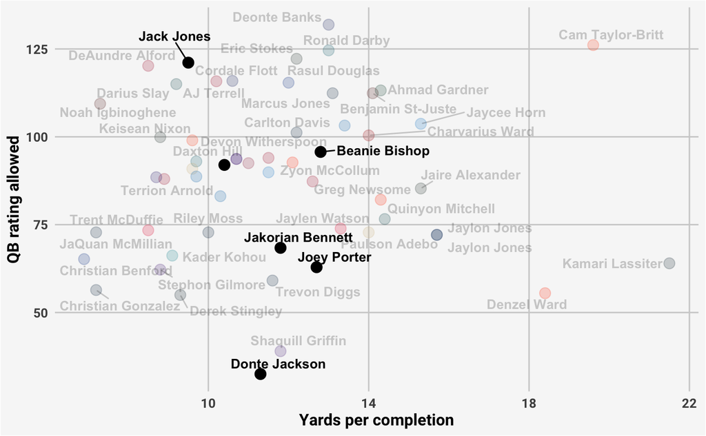